# Assignment 1, Task 2

Dylan Glave

1/25/2021

## Task 2: Principal Component Analysis

### Description

The USDA gathers nutrient information for thousands of food types, from restaurant foods like steak dinners, to raw vegetables. The amounts of macronurtients may be correlated with one another (like protein, fats, carbohydrates and calories.) This multitude of variables makes visualization on standard Cartesian coordinates (X an Y plot,) a bit difficult, so I am going to explore them in multivariate space, using Principal Component Analysis.

### This Principal Component Analysis

To run the PCA, I take the USDA data, and select three food groups to visually explore together: - Vegetables and Vegatable Products - Snacks - Poultry Products

From there, I put them all into a dataframe that includes their macronutrient and caloric amounts, to compare. I scale this data so no one variable carries too much weight. I then run the PCA using prcomp(), and view their rotated values using $rotation.

```r
usda_raw <- read.csv("usda_nutrients.csv")

select_foods <- usda_raw %>%
  filter(FoodGroup == c("Vegetables and Vegetable Products", "Poultry Products", "Snacks")) %>%
    mutate(across(where(is.character), tolower)) %>%
  clean_names()
three_food_pca <- select_foods %>%
  select(energy_kcal,
         ends_with("_g")) %>%
  drop_na() %>%
   scale() %>%
  prcomp()

three_food_pca$rotation
```

```
##                     PC1        PC2         PC3           PC4         PC5
## energy_kcal -0.56207963  0.2817119  0.08656909  0.0436691453  0.17816334
## protein_g   -0.07198511  0.6116444 -0.09801057 -0.7434570891  0.03976954
## fat_g       -0.39295786  0.4604397  0.15211876  0.5058411436 -0.42997589
## carb_g      -0.53005716 -0.2724528  0.06826347  0.0001295552  0.65591432
## sugar_g     -0.36809130 -0.2538611 -0.83179973 -0.0793271571 -0.31916031
## fiber_g     -0.32865933 -0.4425482  0.51303890 -0.4280145854 -0.49970995
##                      PC6
## energy_kcal  0.750707351
## protein_g   -0.238313238
## fat_g       -0.411928082
## carb_g      -0.458176133
## sugar_g     -0.004057482
## fiber_g      0.004324041
```

To visualize the PCA, I am creating a biplot. A biplot takes two Principal components (newly made axes) to account for as much variance as possible within the data. Each variable has a vector (a red arrow) that shows two things: how closely that variable correlated with other variables/vectors, and how powerfully it related to Principal Components 1 and 2.

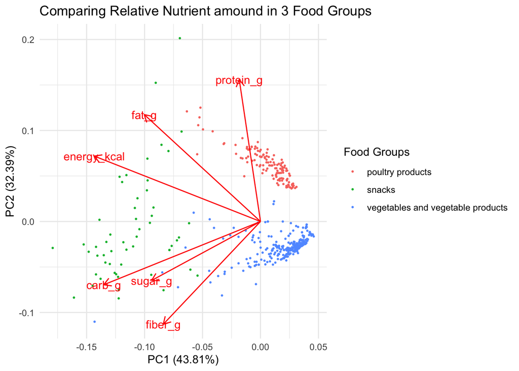

```r
food_graphable <- select_foods %>%
drop_na(energy_kcal, ends_with( "_g"))


### Then, we make an autoplot of the above PCA, to visualize how Fat and micro nutrients relate to one another.

autoplot(three_food_pca,
         data = food_graphable,
         colour = "food_group",
         loadings = TRUE,
         loadings.label = TRUE,
         size = 0.4) +
  theme_minimal() +
  labs( color = "Food Groups", title = "Comparing Relative Nutrient amound in 3 Food Groups") +
  theme_minimal()
```